# wine-quality

## 1. Introdução

Neste projeto, analisamos uma base de dados de vinhos com o objetivo de desenvolver modelos de classificação que preveem se um vinho é de boa qualidade ou não. Consideramos que um vinho é **bom** se sua qualidade (variável `quality`) for igual ou superior a 7, e **ruim** caso contrário.

## 2. Importação das Bibliotecas e Configuração do Notebook no Kaggle

```python
# 2.1. Importação das bibliotecas
import pandas as pd
import numpy as np
import math
import matplotlib.pyplot as plt
import seaborn as sns
import joblib

from sklearn.model_selection import train_test_split, cross_val_score, GridSearchCV
from sklearn.linear_model import LogisticRegression
from sklearn.tree import DecisionTreeClassifier, plot_tree
from sklearn.ensemble import RandomForestClassifier, GradientBoostingClassifier
from sklearn.metrics import accuracy_score, confusion_matrix, classification_report, roc_curve, auc
from sklearn.metrics import accuracy_score
from sklearn.metrics import confusion_matrix, classification_report

# Importa a biblioteca de warnings para controlar a exibição de mensagens de aviso.
import warnings

# Ignora todas as mensagens de aviso, evitando que apareçam no terminal durante a execução do código.
warnings.filterwarnings("ignore")

# Configurações do pandas para melhor visualização dos dados:

# Exibe todo o conteúdo da célula, sem truncamento.
pd.set_option('display.max_colwidth', None)

# Evita que quebre a linha automaticamente ao exibir dataframes grandes.
pd.set_option('display.expand_frame_repr', False)

# Aumenta a largura do display para acomodar mais informações.
pd.set_option('display.width', 300)

# Configuração para exibir gráficos no notebook
%matplotlib inline
```

### 2.2. Adicionando o Dataset

No Kaggle, adicione o dataset “Wine Quality Dataset” usando o botão **"Add Data"**. Ele ficará disponível no caminho:

`../input/wine-quality-dataset/`

### 2.3. Sobre os Dados

Utilizou-se a base de dados de acesso livre "Wine Quality Dataset", disponibilizada na plataforma Kaggle. Essa base contém informações físico-químicas de vinhos, bem como a avaliação de sua qualidade. Com ela, é possível classificar os vinhos como bom se sua qualidade for igual ou superior a 7, ou ruim caso contrário.

Para obter o dataset completo e mais detalhes, acesse o link abaixo:

[Wine Quality Dataset - Kaggle](https://www.kaggle.com/datasets/yasserh/wine-quality-dataset)

```python
# Criação de um dicionário com informações sobre variáveis relacionadas a um vinho e suas características físico-químicas
dictionary = {
    "fixed acidity": (
        "Acidez fixa.",
        "Representa os ácidos não voláteis presentes no vinho, como o ácido tartárico. Contribui para a estabilidade e sabor do vinho."
    ),
    "volatile acidity": (
        "Acidez volátil.",
        "Refere-se aos ácidos que podem evaporar facilmente, como o ácido acético. Níveis altos podem indicar deterioração."
    ),
    "citric acid": (
        "Ácido cítrico.",
        "Um ácido natural presente em pequenas quantidades, contribui para a acidez e frescor do vinho."
    ),
    "residual sugar": (
        "Açúcar residual.",
        "Quantidade de açúcar que permanece após a fermentação. Afeta o sabor e a doçura do vinho."
    ),
    "chlorides": (
        "Cloretos.",
        "Quantidade de sal no vinho, geralmente representada por cloreto de sódio. Pode influenciar o sabor final."
    ),
    "free sulfur dioxide": (
        "Dióxido de enxofre livre.",
        "Porção do SO₂ disponível para proteger o vinho contra microrganismos e oxidação."
    ),
    "total sulfur dioxide": (
        "Dióxido de enxofre total.",
        "Soma do SO₂ livre e combinado. Usado como conservante no processo de vinificação."
    ),
    "density": (
        "Densidade.",
        "Relacionada ao teor de açúcar e álcool no vinho. Afeta a percepção na boca e o corpo do vinho."
    ),
    "pH": (
        "pH.",
        "Mede a acidez geral do vinho. Valores mais baixos indicam maior acidez."
    ),
    "sulphates": (
        "Sulfatos.",
        "Adicionados como conservantes, ajudam na estabilidade microbiológica e podem influenciar o sabor."
    ),
    "alcohol": (
        "Teor alcoólico.",
        "Percentual de álcool presente no vinho. Contribui para o corpo e a sensação térmica na degustação."
    ),
    "quality": (
        "Nota de qualidade.",
        "Avaliação sensorial do vinho em uma escala geralmente de 0 a 10, feita por especialistas."
    ),
    "Id": (
        "Identificador.",
        "Identificação única do registro da amostra de vinho no conjunto de dados."
    )
}


# Criação de um DataFrame a partir do dicionário, onde "items()" converte as chaves e valores do dicionário em pares
dict_df = pd.DataFrame(dictionary.items(), columns=["Variável", "Info"])

# Separação da coluna "Info" em duas colunas: "Descrição" (primeiro valor da tupla) e "Categorias" (segundo valor da tupla)
dict_df["Descrição"] = dict_df["Info"].apply(lambda x: x[0])
dict_df["Categorias"] = dict_df["Info"].apply(lambda x: x[1])

# Adição de uma nova coluna "Tipo" para indicar o tipo de variável (Numérica ou Categórica)
dict_df["Tipo"] = dict_df["Variável"].apply(lambda x: "Categórica" if x in [
    "Id"
] else "Numérica")

# Remoção da coluna auxiliar "Info" que não será mais necessária
dict_df.drop(columns=["Info"], inplace=True)

# Exibição do DataFrame resultante
display(dict_df)
```

|  | Variável | Descrição | Categorias | Tipo |
| --- | --- | --- | --- | --- |
| 0 | fixed acidity | Acidez fixa. | Representa os ácidos não voláteis presentes no vinho, como o ácido tartárico. Contribui para a estabilidade e sabor do vinho. | Numérica |
| 1 | volatile acidity | Acidez volátil. | Refere-se aos ácidos que podem evaporar facilmente, como o ácido acético. Níveis altos podem indicar deterioração. | Numérica |
| 2 | citric acid | Ácido cítrico. | Um ácido natural presente em pequenas quantidades, contribui para a acidez e frescor do vinho. | Numérica |
| 3 | residual sugar | Açúcar residual. | Quantidade de açúcar que permanece após a fermentação. Afeta o sabor e a doçura do vinho. | Numérica |
| 4 | chlorides | Cloretos. | Quantidade de sal no vinho, geralmente representada por cloreto de sódio. Pode influenciar o sabor final. | Numérica |
| 5 | free sulfur dioxide | Dióxido de enxofre livre. | Porção do SO₂ disponível para proteger o vinho contra microrganismos e oxidação. | Numérica |
| 6 | total sulfur dioxide | Dióxido de enxofre total. | Soma do SO₂ livre e combinado. Usado como conservante no processo de vinificação. | Numérica |
| 7 | density | Densidade. | Relacionada ao teor de açúcar e álcool no vinho. Afeta a percepção na boca e o corpo do vinho. | Numérica |
| 8 | pH | pH. | Mede a acidez geral do vinho. Valores mais baixos indicam maior acidez. | Numérica |
| 9 | sulphates | Sulfatos. | Adicionados como conservantes, ajudam na estabilidade microbiológica e podem influenciar o sabor. | Numérica |
| 10 | alcohol | Teor alcoólico. | Percentual de álcool presente no vinho. Contribui para o corpo e a sensação térmica na degustação. | Numérica |
| 11 | quality | Nota de qualidade. | Avaliação sensorial do vinho em uma escala geralmente de 0 a 10, feita por especialistas. | Numérica |
| 12 | Id | Identificador. | Identificação única do registro da amostra de vinho no conjunto de dados. | Categórica |

### 2.4. Carregamento do Dataset

Carregue o dataset.

```python
# Lista de nomes das colunas

columns = ["fixed acidity", "volatile acidity", "citric acid", "residual sugar", "chlorides", "free sulfur dioxide",
           "density", "pH", "sulphates", "alcohol", "alcohol", "quality",
           "Id"]

# Carrega o dataset a partir do diretório do Kaggle
df = pd.read_csv("../input/wine-quality-dataset/WineQT.csv")

# Exibe as primeiras linhas do dataset
df.head()
```

|  | fixed acidity | volatile acidity | citric acid | residual sugar | chlorides | free sulfur dioxide | total sulfur dioxide | density | pH | sulphates | alcohol | quality | Id |
| --- | --- | --- | --- | --- | --- | --- | --- | --- | --- | --- | --- | --- | --- |
| 0 | 7.4 | 0.70 | 0.00 | 1.9 | 0.076 | 11.0 | 34.0 | 0.9978 | 3.51 | 0.56 | 9.4 | 5 | 0 |
| 1 | 7.8 | 0.88 | 0.00 | 2.6 | 0.098 | 25.0 | 67.0 | 0.9968 | 3.20 | 0.68 | 9.8 | 5 | 1 |
| 2 | 7.8 | 0.76 | 0.04 | 2.3 | 0.092 | 15.0 | 54.0 | 0.9970 | 3.26 | 0.65 | 9.8 | 5 | 2 |
| 3 | 11.2 | 0.28 | 0.56 | 1.9 | 0.075 | 17.0 | 60.0 | 0.9980 | 3.16 | 0.58 | 9.8 | 6 | 3 |
| 4 | 7.4 | 0.70 | 0.00 | 1.9 | 0.076 | 11.0 | 34.0 | 0.9978 | 3.51 | 0.56 | 9.4 | 5 | 4 |

```python
print( 'Número de instâncias do dataset : {}'.format( df.shape[0] ) )
print( 'Número de atributos do dataset: {}'.format( df.shape[1] ) )
```

```
Número de instâncias do dataset : 1143
Número de atributos do dataset: 13
```

## 3. Análise Exploratória dos Dados (EDA)

Exploramos o dataset para entender a distribuição dos dados, tipos de variáveis e estatísticas descritivas.

```python
# 3.1. Informações gerais dos dados
df.info()
```

```
<class 'pandas.core.frame.DataFrame'>
RangeIndex: 1143 entries, 0 to 1142
Data columns (total 13 columns):
 #   Column                Non-Null Count  Dtype
---  ------                --------------  -----
 0   fixed acidity         1143 non-null   float64
 1   volatile acidity      1143 non-null   float64
 2   citric acid           1143 non-null   float64
 3   residual sugar        1143 non-null   float64
 4   chlorides             1143 non-null   float64
 5   free sulfur dioxide   1143 non-null   float64
 6   total sulfur dioxide  1143 non-null   float64
 7   density               1143 non-null   float64
 8   pH                    1143 non-null   float64
 9   sulphates             1143 non-null   float64
 10  alcohol               1143 non-null   float64
 11  quality               1143 non-null   int64
 12  Id                    1143 non-null   int64
dtypes: float64(11), int64(2)
memory usage: 116.2 KB
```

```python
# 3.2. Estatísticas descritivas
df.describe()
```

|  | fixed acidity | volatile acidity | citric acid | residual sugar | chlorides | free sulfur dioxide | total sulfur dioxide | density | pH | sulphates | alcohol | quality | Id |
| --- | --- | --- | --- | --- | --- | --- | --- | --- | --- | --- | --- | --- | --- |
| count | 1143.000000 | 1143.000000 | 1143.000000 | 1143.000000 | 1143.000000 | 1143.000000 | 1143.000000 | 1143.000000 | 1143.000000 | 1143.000000 | 1143.000000 | 1143.000000 | 1143.000000 |
| mean | 8.311111 | 0.531339 | 0.268364 | 2.532152 | 0.086933 | 15.615486 | 45.914698 | 0.996730 | 3.311015 | 0.657708 | 10.442111 | 5.657043 | 804.969379 |
| std | 1.747595 | 0.179633 | 0.196686 | 1.355917 | 0.047267 | 10.250486 | 32.782130 | 0.001925 | 0.156664 | 0.170399 | 1.082196 | 0.805824 | 463.997116 |
| min | 4.600000 | 0.120000 | 0.000000 | 0.900000 | 0.012000 | 1.000000 | 6.000000 | 0.990070 | 2.740000 | 0.330000 | 8.400000 | 3.000000 | 0.000000 |
| 25% | 7.100000 | 0.392500 | 0.090000 | 1.900000 | 0.070000 | 7.000000 | 21.000000 | 0.995570 | 3.205000 | 0.550000 | 9.500000 | 5.000000 | 411.000000 |
| 50% | 7.900000 | 0.520000 | 0.250000 | 2.200000 | 0.079000 | 13.000000 | 37.000000 | 0.996680 | 3.310000 | 0.620000 | 10.200000 | 6.000000 | 794.000000 |
| 75% | 9.100000 | 0.640000 | 0.420000 | 2.600000 | 0.090000 | 21.000000 | 61.000000 | 0.997845 | 3.400000 | 0.730000 | 11.100000 | 6.000000 | 1209.500000 |
| max | 15.900000 | 1.580000 | 1.000000 | 15.500000 | 0.611000 | 68.000000 | 289.000000 | 1.003690 | 4.010000 | 2.000000 | 14.900000 | 8.000000 | 1597.000000 |

```python
df.shape
```

```
(1143, 13)
```

```python
# verifica linhas duplicadas

df.duplicated().sum()
```

```
0
```

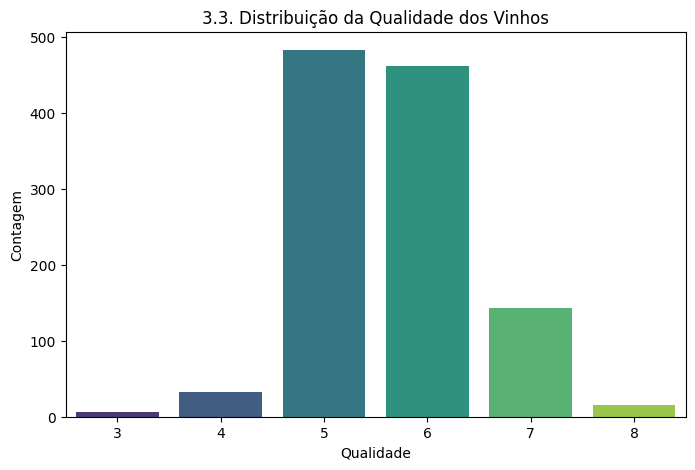

```python
# 3.3. Distribuição da variável 'quality'
plt.figure(figsize=(8,5))
sns.countplot(x='quality', data=df, palette='viridis')
plt.title('3.3. Distribuição da Qualidade dos Vinhos')
plt.xlabel('Qualidade')
plt.ylabel('Contagem')
plt.show()
```

## 4. Criação da Variável de Classificação

Transformamos o problema em uma tarefa de classificação criando a coluna `target`. Um vinho é classificado como **bom** se `quality` ≥ 7 e **ruim** caso contrário.

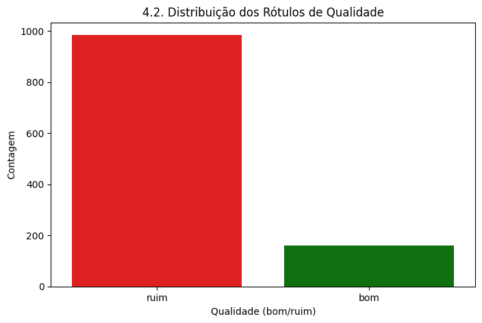

|  | quality | target |
| --- | --- | --- |
| 0 | 5 | ruim |
| 1 | 5 | ruim |
| 2 | 5 | ruim |
| 3 | 6 | ruim |
| 4 | 5 | ruim |

```python
# 4.1. Criando a variável de classificação
df["target"] = df["quality"].apply(lambda x: 'bom' if x >= 7 else 'ruim')

# 4.2. Visualizando a distribuição da nova variável com cores específicas
plt.figure(figsize=(8,5))
# Define o dicionário de cores: 'ruim' em vermelho e 'bom' em verde
sns.countplot(x='target', data=df, palette={'ruim': 'red', 'bom': 'green'})
plt.title('4.2. Distribuição dos Rótulos de Qualidade')
plt.xlabel('Qualidade (bom/ruim)')
plt.ylabel('Contagem')
plt.show()

# 4.3. Conferindo as primeiras linhas
df[['quality', 'target']].head()
```

## 5. Divisão dos Dados em Conjunto de Treino e Teste

Dividimos os dados em 70% para treinamento e 30% para teste. Essa divisão é fundamental para avaliar a performance do modelo em dados que ele não viu durante o treinamento.

```python
# 6.1. Definindo as features e a variável alvo
X = df.drop(['quality', 'target','Id'], axis=1)
y = df['target']

# 6.2. Dividindo os dados
X_train, X_test, y_train, y_test = train_test_split(X, y, test_size=0.3, random_state=42)

print('Tamanho do treino:', X_train.shape)
print('Tamanho do teste:', X_test.shape)
print("Total do número de observações do dataset: ", len(X_train)+len(X_test))

# print proportions
print('train: {}% | Test: {}%'.format( round(len(y_train)/len(y),2),
                                                        round(len(y_test)/len(y),2) ) )
```

```
Tamanho do treino: (800, 11)
Tamanho do teste: (343, 11)
Total do número de observações do dataset:  1143
train: 0.7% | Test: 0.3%
```

```python
df_treino = pd.concat([X_train,y_train], axis = 1)
```

```python
df_treino.shape
```

```
(800, 12)
```

```python
df_treino.head()
```

|  | fixed acidity | volatile acidity | citric acid | residual sugar | chlorides | free sulfur dioxide | total sulfur dioxide | density | pH | sulphates | alcohol | target |
| --- | --- | --- | --- | --- | --- | --- | --- | --- | --- | --- | --- | --- |
| 485 | 9.8 | 0.98 | 0.32 | 2.3 | 0.078 | 35.0 | 152.0 | 0.99800 | 3.25 | 0.48 | 9.4 | ruim |
| 420 | 9.0 | 0.45 | 0.49 | 2.6 | 0.084 | 21.0 | 75.0 | 0.99870 | 3.35 | 0.57 | 9.7 | ruim |
| 922 | 7.6 | 1.58 | 0.00 | 2.1 | 0.137 | 5.0 | 9.0 | 0.99476 | 3.50 | 0.40 | 10.9 | ruim |
| 809 | 7.0 | 0.22 | 0.30 | 1.8 | 0.065 | 16.0 | 20.0 | 0.99672 | 3.61 | 0.82 | 10.0 | ruim |
| 615 | 7.2 | 0.62 | 0.06 | 2.5 | 0.078 | 17.0 | 84.0 | 0.99746 | 3.51 | 0.53 | 9.7 | ruim |

```python
pd.DataFrame.info(df_treino);
```

```
<class 'pandas.core.frame.DataFrame'>
Index: 800 entries, 485 to 1126
Data columns (total 12 columns):
 #   Column                Non-Null Count  Dtype
---  ------                --------------  -----
 0   fixed acidity         800 non-null    float64
 1   volatile acidity      800 non-null    float64
 2   citric acid           800 non-null    float64
 3   residual sugar        800 non-null    float64
 4   chlorides             800 non-null    float64
 5   free sulfur dioxide   800 non-null    float64
 6   total sulfur dioxide  800 non-null    float64
 7   density               800 non-null    float64
 8   pH                    800 non-null    float64
 9   sulphates             800 non-null    float64
 10  alcohol               800 non-null    float64
 11  target                800 non-null    object
dtypes: float64(11), object(1)
memory usage: 81.2+ KB
```

```python
# separando em listas: variáveis numéricas e categóricas
num_vars = df[['fixed acidity', 'volatile acidity', 'citric acid','residual sugar','chlorides','free sulfur dioxide','total sulfur dioxide','density', 'pH', 'sulphates', 'alcohol']].columns.tolist()  # Seleciona as colunas com tipo numérico
cat_vars = df[['target']].columns.tolist()  # Seleciona as colunas com tipo categorico

# Exibindo os resultados
print("Variáveis Numéricas:", num_vars)  # Imprime as variáveis numéricas
print("Variáveis Categóricas:", cat_vars)  # Imprime as variáveis categóricas
print("Qtd Variáveis Numéricas:", len(num_vars))  # Imprime a quantidade de variáveis numéricas
print("Qtd Variáveis Categóricas:", len(cat_vars))  # Imprime a quantidade de variáveis categóricas
```

```
Variáveis Numéricas: ['fixed acidity', 'volatile acidity', 'citric acid', 'residual sugar', 'chlorides', 'free sulfur dioxide', 'total sulfur dioxide', 'density', 'pH', 'sulphates', 'alcohol']
Variáveis Categóricas: ['target']
Qtd Variáveis Numéricas: 11
Qtd Variáveis Categóricas: 1
```

```python
# Calcular percentual de valores ausentes e zeros para cada variável

# Percentual de valores ausentes (NaN) para cada variável
missing_percent = df_treino.isnull().mean() * 100  # O método isnull() retorna um DataFrame booleano onde True indica valores ausentes. Mean() calcula a média (porcentagem) de valores ausentes.

# Percentual de zeros para cada variável
zeros_percent = (df_treino == 0).mean() * 100  # O código (df == 0) cria um DataFrame booleano, onde True representa zeros. Mean() calcula a porcentagem de zeros.

# Criar um DataFrame para mostrar os resultados de valores ausentes e zeros
missing_zeros_df = pd.DataFrame({
    'features': df_treino.columns,  # Coluna com o nome das variáveis
    'missing': missing_percent,  # Coluna com percentual de valores ausentes
    'zeros': zeros_percent  # Coluna com percentual de zeros
})

# Resetando o índice para garantir que não haja problemas com duplicação de colunas
missing_zeros_df.reset_index(drop=True, inplace=True)

# Ordenar o DataFrame pelas variáveis com maior percentual de valores ausentes
missing_zeros_df = missing_zeros_df.sort_values(by='missing', ascending=False)  # Ordena o DataFrame pela coluna 'missing', de forma decrescente.

# Exibir o DataFrame corrigido com a coluna 'features' com o nome correto
missing_zeros_df = missing_zeros_df[['features', 'missing', 'zeros']]  # Selecionando apenas as colunas desejadas

# Exibir o DataFrame final
missing_zeros_df
```

|  | features | missing | zeros |
| --- | --- | --- | --- |
| 0 | fixed acidity | 0.0 | 0.00 |
| 1 | volatile acidity | 0.0 | 0.00 |
| 2 | citric acid | 0.0 | 8.25 |
| 3 | residual sugar | 0.0 | 0.00 |
| 4 | chlorides | 0.0 | 0.00 |
| 5 | free sulfur dioxide | 0.0 | 0.00 |
| 6 | total sulfur dioxide | 0.0 | 0.00 |
| 7 | density | 0.0 | 0.00 |
| 8 | pH | 0.0 | 0.00 |
| 9 | sulphates | 0.0 | 0.00 |
| 10 | alcohol | 0.0 | 0.00 |
| 11 | target | 0.0 | 0.00 |

```python
df_treino['target'].value_counts()
```

```
target
ruim    686
bom     114
Name: count, dtype: int64
```

```python
df_treino['target'].value_counts(normalize=True)
```

```
target
ruim    0.8575
bom     0.1425
Name: proportion, dtype: float64
```

```python
df_treino.head()
```

|  | fixed acidity | volatile acidity | citric acid | residual sugar | chlorides | free sulfur dioxide | total sulfur dioxide | density | pH | sulphates | alcohol | target |
| --- | --- | --- | --- | --- | --- | --- | --- | --- | --- | --- | --- | --- |
| 485 | 9.8 | 0.98 | 0.32 | 2.3 | 0.078 | 35.0 | 152.0 | 0.99800 | 3.25 | 0.48 | 9.4 | ruim |
| 420 | 9.0 | 0.45 | 0.49 | 2.6 | 0.084 | 21.0 | 75.0 | 0.99870 | 3.35 | 0.57 | 9.7 | ruim |
| 922 | 7.6 | 1.58 | 0.00 | 2.1 | 0.137 | 5.0 | 9.0 | 0.99476 | 3.50 | 0.40 | 10.9 | ruim |
| 809 | 7.0 | 0.22 | 0.30 | 1.8 | 0.065 | 16.0 | 20.0 | 0.99672 | 3.61 | 0.82 | 10.0 | ruim |
| 615 | 7.2 | 0.62 | 0.06 | 2.5 | 0.078 | 17.0 | 84.0 | 0.99746 | 3.51 | 0.53 | 9.7 | ruim |

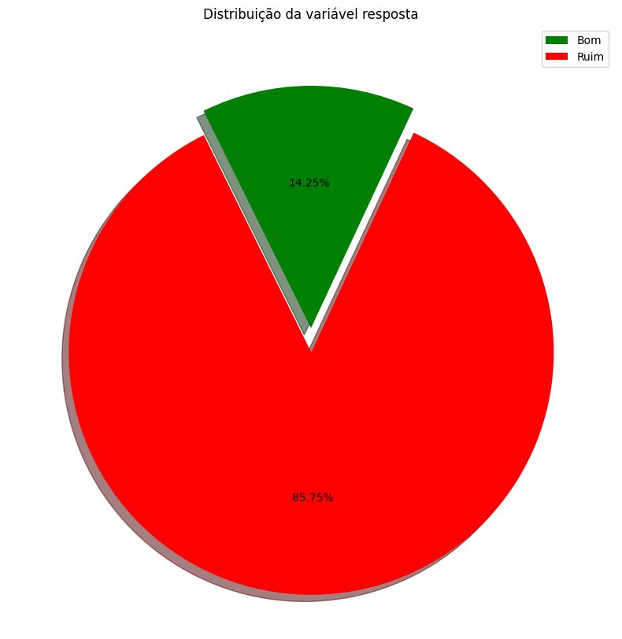

```python
# Define o tamanho da figura do gráfico (10x10 polegadas)
plt.figure(figsize=(10,10))

# O explode destaca a segunda fatia (0.1), enquanto a primeira não é destacada (0).
explode = [0, 0.1]

# Define as cores: verde para "Bom" e vermelho para "Ruim"
colors = ['green', 'red']

# Obtem os contagens e reordena para que "bom" seja a primeira fatia e "ruim" a segunda.
counts = df_treino['target'].value_counts()
counts = counts.reindex(['bom', 'ruim'])

# Cria o gráfico de pizza usando os valores reordenados
plt.pie(counts, explode=explode, autopct='%1.2f%%', shadow=True, startangle=65, colors=colors)

# Adiciona uma legenda com os rótulos na ordem correta
plt.legend(labels=['Bom', 'Ruim'])

# Define o título do gráfico
plt.title('Distribuição da variável resposta')
plt.show()
```

```python
df_treino[num_vars].describe(percentiles = [0.01,0.75, 0.99])
```

|  | fixed acidity | volatile acidity | citric acid | residual sugar | chlorides | free sulfur dioxide | total sulfur dioxide | density | pH | sulphates | alcohol |
| --- | --- | --- | --- | --- | --- | --- | --- | --- | --- | --- | --- |
| count | 800.000000 | 800.000000 | 800.000000 | 800.000000 | 800.000000 | 800.000000 | 800.000000 | 800.000000 | 800.000000 | 800.000000 | 800.000000 |
| mean | 8.242250 | 0.529556 | 0.264437 | 2.505187 | 0.086559 | 15.703125 | 45.541250 | 0.996686 | 3.314925 | 0.658013 | 10.437125 |
| std | 1.687424 | 0.177821 | 0.192712 | 1.294620 | 0.046372 | 10.212862 | 30.899422 | 0.001887 | 0.151320 | 0.168291 | 1.067080 |
| min | 4.600000 | 0.120000 | 0.000000 | 0.900000 | 0.012000 | 1.000000 | 6.000000 | 0.990070 | 2.740000 | 0.390000 | 8.400000 |
| 1% | 5.199000 | 0.180000 | 0.000000 | 1.400000 | 0.041000 | 3.000000 | 8.990000 | 0.991819 | 2.939900 | 0.420000 | 9.000000 |
| 50% | 7.900000 | 0.520000 | 0.250000 | 2.200000 | 0.079000 | 14.000000 | 38.000000 | 0.996655 | 3.320000 | 0.620000 | 10.200000 |
| 75% | 9.000000 | 0.640000 | 0.420000 | 2.600000 | 0.090000 | 21.000000 | 62.000000 | 0.997800 | 3.400000 | 0.730000 | 11.100000 |
| 99% | 13.003000 | 1.000050 | 0.690000 | 7.306000 | 0.341170 | 48.000000 | 141.010000 | 1.002101 | 3.680000 | 1.170500 | 13.567000 |
| max | 15.600000 | 1.580000 | 1.000000 | 15.500000 | 0.610000 | 68.000000 | 165.000000 | 1.003200 | 4.010000 | 2.000000 | 14.000000 |

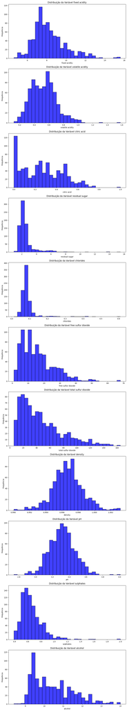

```python
# Criar uma figura com múltiplos histogramas
# Utiliza o método subplots do matplotlib para criar uma figura com múltiplos subgráficos (axes)
# nrows= len(num_vars) cria uma linha de gráficos, uma para cada variável numérica
# ncols=1 define que teremos uma coluna de subgráficos
# figsize=(10, 5 * len(num_vars)) define o tamanho da figura com base no número de variáveis numéricas, aumentando a altura conforme necessário
fig, axes = plt.subplots(nrows=len(num_vars), ncols=1, figsize=(10, 5 * len(num_vars)))

# Criar um histograma para cada variável numérica
# O loop for percorre todas as variáveis numéricas
for i, var in enumerate(num_vars):
    # Utiliza o Seaborn para criar um histograma para cada variável, passando o eixo específico (ax=axes[i])
    # color="blue" define a cor do histograma
    # bins=30 define o número de barras (bins) no histograma
    sns.histplot(df_treino[var], ax=axes[i], color="blue", bins=30)

    # Define o título do gráfico para cada variável
    axes[i].set_title(f'Distribuição da Variável {var}')

    # Define o rótulo no eixo x (nome da variável)
    axes[i].set_xlabel(var)

    # Define o rótulo no eixo y (Frequência)
    axes[i].set_ylabel('Frequência')

# Ajusta o layout dos subgráficos para que fiquem bem organizados e sem sobreposição
plt.tight_layout()

# Exibe os gráficos gerados
plt.show()
```

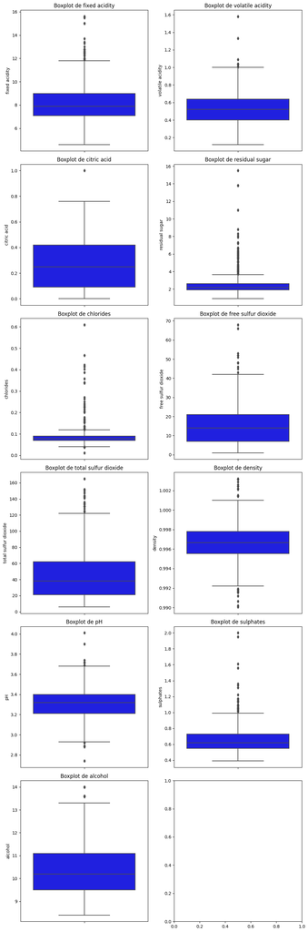

```python
# Calcular o número de linhas necessárias para exibir 2 boxplots por linha
ncols = 2  # número de colunas (2 boxplots por linha)
nrows = math.ceil(len(num_vars) / ncols)  # número de linhas necessárias

# Criar uma figura com múltiplos boxplots
fig, axes = plt.subplots(nrows=nrows, ncols=ncols, figsize=(10, 5 * nrows))

# Fazer o loop para criar um boxplot para cada variável numérica
for i, var in enumerate(num_vars):
    row = i // ncols  # Calcula a linha onde o boxplot será colocado
    col = i % ncols   # Calcula a coluna onde o boxplot será colocado
    sns.boxplot(y=df_treino[var], ax=axes[row, col], color="blue")  # Cria o boxplot
    axes[row, col].set_title(f'Boxplot de {var}')  # Define o título para cada boxplot
    axes[row, col].set_ylabel(var)  # Define o rótulo do eixo y (nome da variável)

# Ajusta o layout dos gráficos para que fiquem bem organizados
plt.tight_layout()

# Exibe os gráficos gerados
plt.show()
```

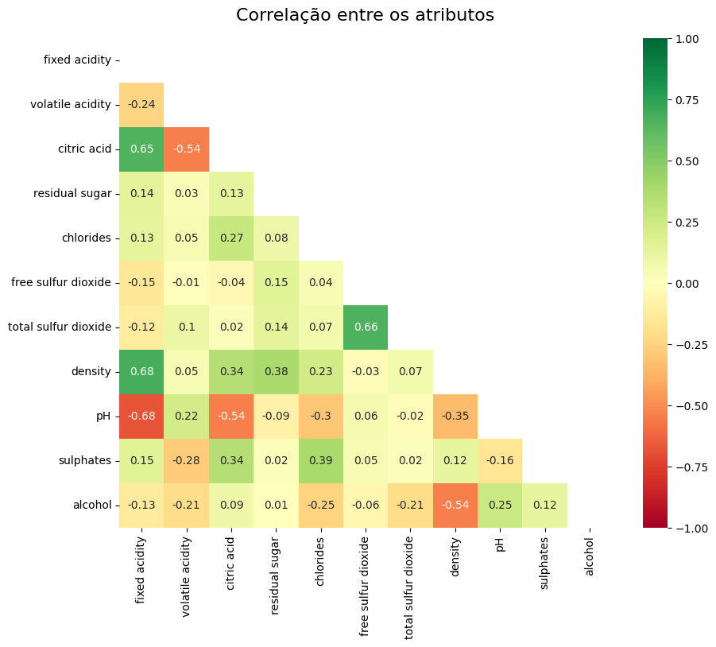

```python
# Criando uma matriz de correlação com um gráfico de calor (heatmap)
plt.figure(figsize=(10, 8))  # Define o tamanho da figura do gráfico de calor

# Definindo uma máscara para ocultar a parte superior da matriz de correlação
# np.triu cria uma matriz triangular superior com 1s acima da diagonal e 0s na diagonal e abaixo
mask = np.triu(np.ones_like(df_treino[num_vars].corr(method='pearson').round(2), dtype=bool))

# Gerando o gráfico de calor (heatmap)
# df[num_vars].corr(method='pearson') calcula a matriz de correlação de Pearson entre as variáveis numéricas
# round(2) arredonda os valores da correlação para duas casas decimais
# O parâmetro mask é utilizado para ocultar a parte superior da matriz, deixando visível apenas a parte inferior (para evitar redundância)
# vmin e vmax definem os valores mínimo e máximo da escala de cores, respectivamente -1 e 1
# annot=True adiciona os valores numéricos de correlação em cada célula
# cmap="RdYlGn" define o mapa de cores, variando de vermelho para verde (indicando correlação negativa e positiva, respectivamente)
# square=False faz com que o gráfico não seja quadrado
# center=0 centraliza o gráfico de calor em torno de 0, destacando correlações negativas e positivas
heatmap = sns.heatmap(df_treino[num_vars].corr(method='pearson').round(2), mask=mask, vmin=-1, vmax=1, annot=True, cmap="RdYlGn", square=False, center=0)

# Adicionando título ao gráfico
heatmap.set_title('Correlação entre os atributos', fontdict={'fontsize': 16}, pad=16)
```

```python
cor_matrix = df_treino[num_vars].corr().abs()
```

```python
upper_tri = cor_matrix.where(np.triu(np.ones(cor_matrix.shape),k=1).astype(bool))
```

```python
to_drop = [column for column in upper_tri.columns if any(upper_tri[column] > 0.7)]
to_drop
```

```
[]
```

```python
df_treino[cat_vars].apply( lambda x: x.unique().shape[0] )
```

```
target    2
dtype: int64
```

```python
# Define um threshold (percentual mínimo)
threshold = 5  # Percentual mínimo para ser considerado como "baixo"

# Nome da variável numérica que será analisada como se fosse categórica
var = 'target'

# Calcula o percentual de ocorrência de cada valor de 'quality'
value_counts = df_treino[var].value_counts(normalize=True) * 100

# Exibe os resultados
print(f"Percentual de ocorrência para cada valor da variável '{var}':")
print(value_counts.sort_index())  # Ordena pelos valores numéricos

print("\n" + "="*50 + "\n")

# Verifica se existe algum valor com frequência abaixo do threshold
low_freq_values = value_counts[value_counts < threshold]

if not low_freq_values.empty:
    print(f"Atenção! Os valores abaixo da variável '{var}' aparecem em menos de {threshold}% dos casos:")
    for value, pct in low_freq_values.items():
        print(f"Valor: {value}, Percentual: {pct:.2f}%")
    print("="*50 + "\n")
else:
    print(f"Nenhum valor da variável '{var}' aparece em menos de {threshold}% dos casos.")
```

```
Percentual de ocorrência para cada valor da variável 'target':
target
bom     14.25
ruim    85.75
Name: proportion, dtype: float64

==================================================

Nenhum valor da variável 'target' aparece em menos de 5% dos casos.
```

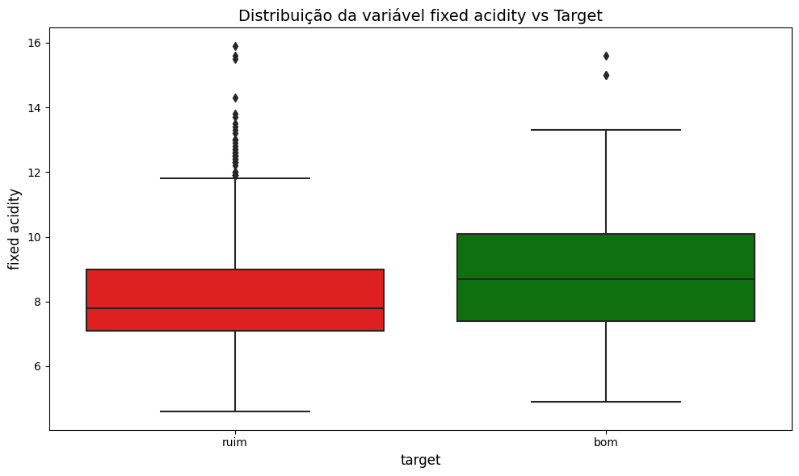

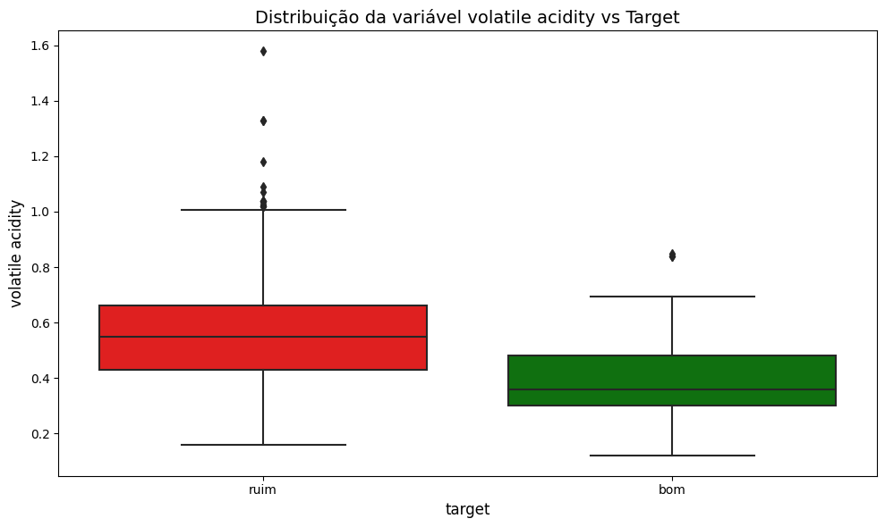

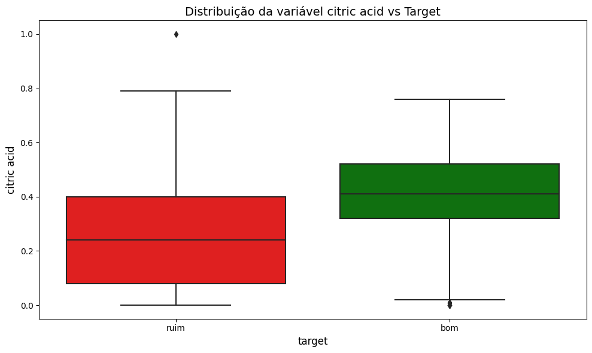

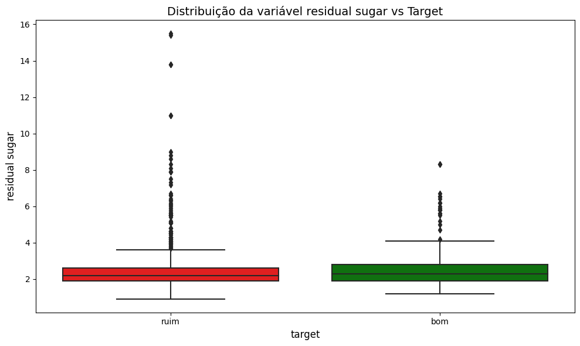

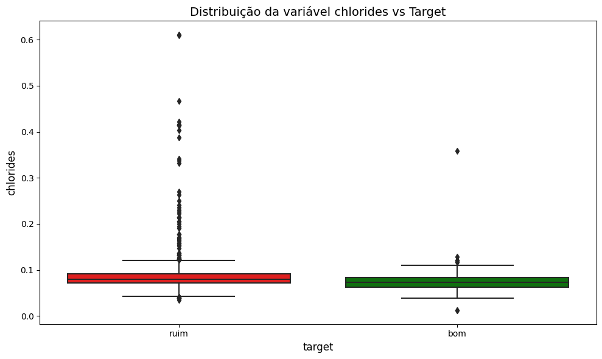

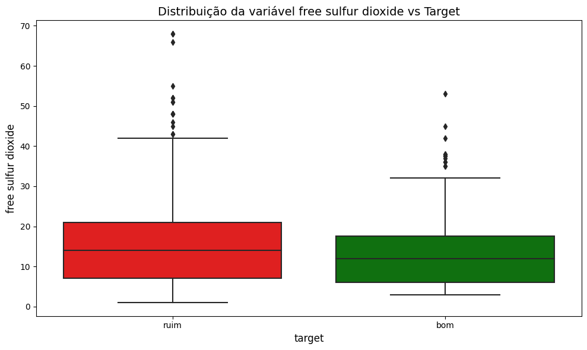

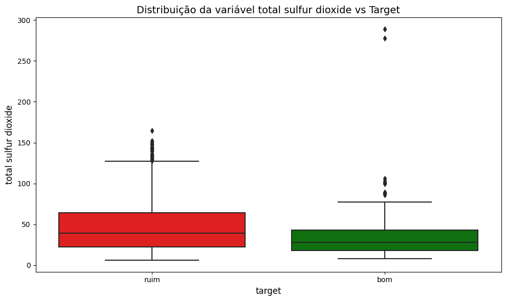

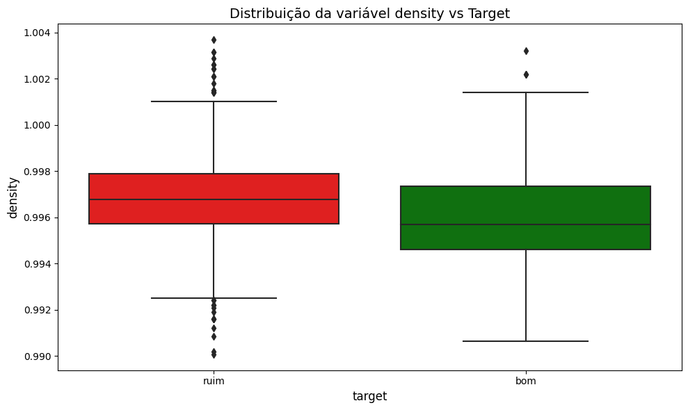

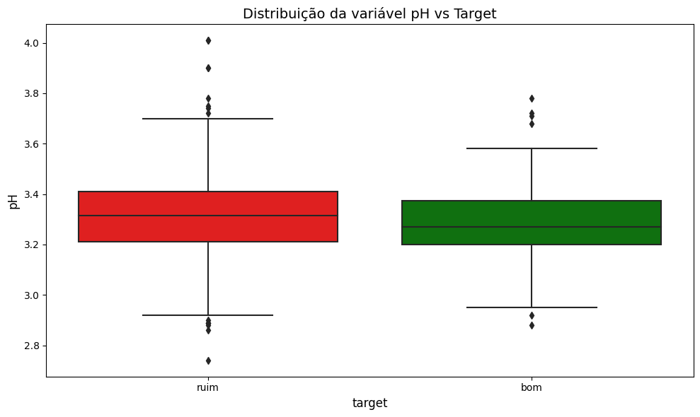

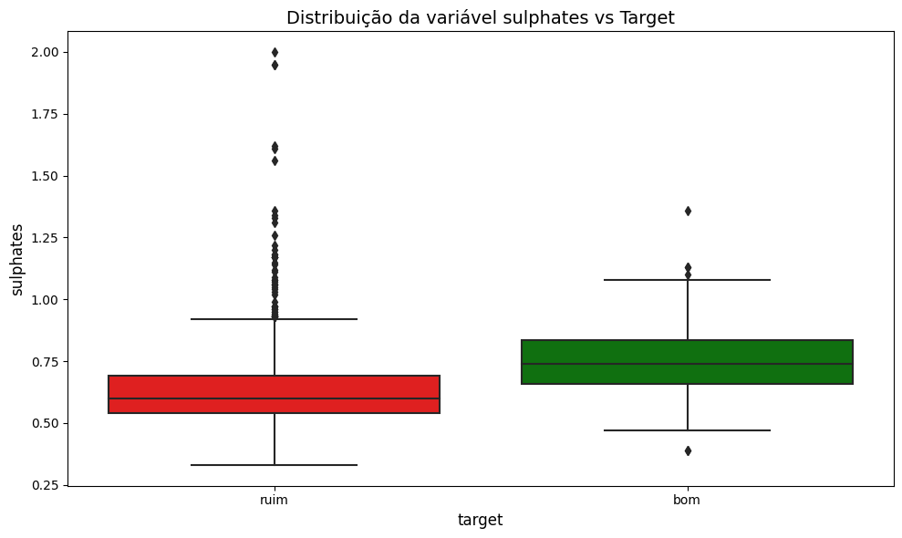

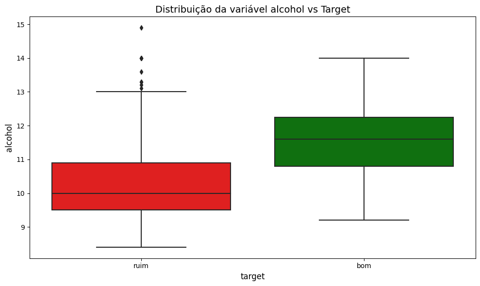

```python
# Plotar Boxplot para cada variável numérica em relação ao target
for num_var in num_vars:  # num_vars é a lista de variáveis numéricas
    plt.figure(figsize=(10, 6))

    # Definir uma paleta customizada com as cores verde e vermelho
    custom_palette = ['red', 'green']  # Verde para 'Adimplente' e vermelho para 'Inadimplente'

    # Criar o boxplot com as cores ajustadas
    sns.boxplot(x='target', y=num_var, data=df, palette=custom_palette)

    # Títulos e rótulos do gráfico
    plt.title(f'Distribuição da variável {num_var} vs Target', fontsize=14)
    plt.xlabel('target', fontsize=12)
    plt.ylabel(num_var, fontsize=12)

    # Ajuste no layout para evitar sobreposição
    plt.tight_layout()

    # Mostrar o gráfico
    plt.show()
```

## 6. Modelagem Preditiva

Treinamos e avaliamos vários modelos de classificação. Aqui, destacamos os modelos de Regressão Logística e Árvore de Decisão.

### 6.1. Modelo 1: Regressão Logística

```python
# Treinamento e avaliação da Regressão Logística
log_reg = LogisticRegression(max_iter=5000)  # max_iter aumentado para garantir convergência
log_reg.fit(X_train, y_train)

y_pred_log = log_reg.predict(X_test)
acc_log = accuracy_score(y_test, y_pred_log)
print('Acurácia da Regressão Logística:', acc_log)
```

```
Acurácia da Regressão Logística: 0.8833819241982507
```

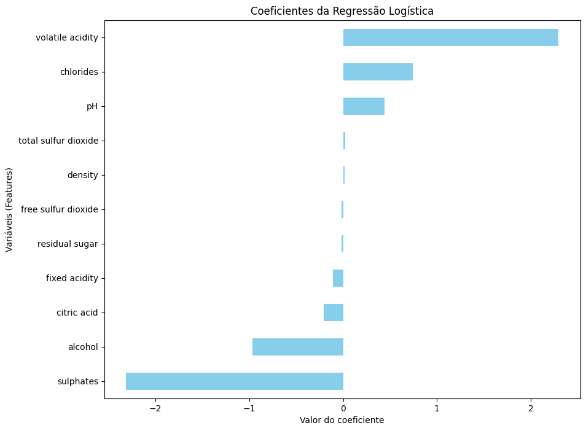

```python
# Cria uma série com os coeficientes do modelo, associando cada coeficiente à sua feature
coeficientes = pd.Series(log_reg.coef_[0], index=X.columns)

# Ordena os coeficientes para uma visualização mais clara
coeficientes_ordenados = coeficientes.sort_values()

# Plota os coeficientes em um gráfico de barras horizontal
plt.figure(figsize=(10,8))
coeficientes_ordenados.plot(kind='barh', color='skyblue')
plt.title("Coeficientes da Regressão Logística")
plt.xlabel("Valor do coeficiente")
plt.ylabel("Variáveis (Features)")
plt.show()
```

### 6.2. Modelo 2: Árvore de Decisão

```python
# Definindo o grid de parâmetros para a Árvore de Decisão
param_grid_tree = {
    'max_depth': [3, 5, 7, 10],
    'min_samples_split': [2, 10, 20],
    'min_samples_leaf': [1, 5, 10]
}

# Configurando o GridSearchCV para a árvore de decisão
grid_search_tree = GridSearchCV(DecisionTreeClassifier(random_state=42),
                                param_grid_tree,
                                cv=5,
                                scoring='accuracy',
                                n_jobs=-1)

# Executa o GridSearchCV no conjunto de treino
grid_search_tree.fit(X_train, y_train)

# Exibe os melhores parâmetros e a melhor acurácia encontrada
print("Melhores parâmetros para a Árvore de Decisão:", grid_search_tree.best_params_)
print("Melhor acurácia (treino):", grid_search_tree.best_score_)

# Seleciona o melhor modelo
tree_clf = grid_search_tree.best_estimator_
```

```
Melhores parâmetros para a Árvore de Decisão: {'max_depth': 3, 'min_samples_leaf': 10, 'min_samples_split': 2}
Melhor acurácia (treino): 0.8762500000000001
```

```python
# Treinamento e avaliação da Árvore de Decisão Otimizada
tree_clf = DecisionTreeClassifier(
    random_state=42,
    max_depth=3,
    min_samples_leaf=10,
    min_samples_split=2
)
tree_clf.fit(X_train, y_train)

y_pred_tree = tree_clf.predict(X_test)
acc_tree = accuracy_score(y_test, y_pred_tree)
print('Acurácia da Árvore de Decisão Otimizada:', acc_tree)
```

```
Acurácia da Árvore de Decisão Otimizada: 0.8862973760932945
```

[figure not shown]

```python
# Configura o tamanho da figura para melhor visualização
plt.figure(figsize=(20,10))

# Plota a árvore com preenchimento de cores usando o modelo otimizado
plot_tree(tree_clf,
          filled=True,
          feature_names=X.columns,    # Nomes das features conforme o DataFrame X
          class_names=['ruim', 'bom'],  # Ajuste os nomes conforme seus rótulos
          rounded=True,
          proportion=True)
plt.title('Árvore de Decisão Otimizada')
plt.show()
```

## 7. Modelos Adicionais

Foi implementado modelos adicionais para aprimorar a análise: Random Forest e Gradient Boosting.

### 7.1. Modelo 3: Random Forest

```python
# Definindo o grid de parâmetros para o Random Forest
param_grid_rf = {
    'n_estimators': [50, 100, 200],
    'max_depth': [3, 5, 7, 10],
    'min_samples_split': [2, 10, 20],
    'min_samples_leaf': [1, 5, 10]
}

# Configurando o GridSearchCV para o Random Forest
grid_search_rf = GridSearchCV(RandomForestClassifier(random_state=42),
                              param_grid_rf,
                              cv=5,
                              scoring='accuracy',
                              n_jobs=-1)

# Executa o GridSearchCV no conjunto de treino
grid_search_rf.fit(X_train, y_train)

# Exibe os melhores parâmetros e a melhor acurácia encontrada
print("Melhores parâmetros para o Random Forest:", grid_search_rf.best_params_)
print("Melhor acurácia (treino):", grid_search_rf.best_score_)

# Seleciona o melhor modelo
rf_clf = grid_search_rf.best_estimator_
```

```
Melhores parâmetros para o Random Forest: {'max_depth': 10, 'min_samples_leaf': 1, 'min_samples_split': 10, 'n_estimators': 200}
Melhor acurácia (treino): 0.8975
```

```python
# Treinamento e avaliação do Random Forest Classifier Otimizado
rf_clf = RandomForestClassifier(
    random_state=42,
    max_depth=10,
    min_samples_leaf=1,
    min_samples_split=10,
    n_estimators=200
)
rf_clf.fit(X_train, y_train)

y_pred_rf = rf_clf.predict(X_test)
acc_rf = accuracy_score(y_test, y_pred_rf)
print('Acurácia do Random Forest Otimizado:', acc_rf)
```

```
Acurácia do Random Forest Otimizado: 0.8892128279883382
```

[figure not shown]

```python
# Plotar uma árvore individual do Random Forest Otimizado (o primeiro estimador)
plt.figure(figsize=(20,10))
plot_tree(rf_clf.estimators_[0],
          filled=True,
          feature_names=X.columns,    # Certifique-se de que X contém as mesmas colunas usadas no treinamento
          class_names=['ruim', 'bom'],  # Ajuste os nomes conforme seus rótulos
          rounded=True,
          proportion=True)
plt.title('Árvore do Random Forest Otimizado - Estimador 0')
plt.show()
```

### 7.2. Modelo 4: Gradient Boosting

```python
# Treinamento e avaliação do Gradient Boosting Classifier
gb_clf = GradientBoostingClassifier(random_state=42)
gb_clf.fit(X_train, y_train)

y_pred_gb = gb_clf.predict(X_test)
acc_gb = accuracy_score(y_test, y_pred_gb)
print('Acurácia do Gradient Boosting:', acc_gb)
```

```
Acurácia do Gradient Boosting: 0.892128279883382
```

## 8. Validação Cruzada

Realizamos a validação cruzada para obter uma estimativa mais robusta do desempenho de cada modelo.

```python
# Validação cruzada para Regressão Logística
cv_log = cross_val_score(log_reg, X, y, cv=5, scoring='accuracy')
print('Validação Cruzada - Regressão Logística:', cv_log.mean())

# Validação cruzada para Árvore de Decisão
cv_tree = cross_val_score(tree_clf, X, y, cv=5, scoring='accuracy')
print('Validação Cruzada - Árvore de Decisão:', cv_tree.mean())

# Validação cruzada para Random Forest
cv_rf = cross_val_score(rf_clf, X, y, cv=5, scoring='accuracy')
print('Validação Cruzada - Random Forest:', cv_rf.mean())

# Validação cruzada para Gradient Boosting
cv_gb = cross_val_score(gb_clf, X, y, cv=5, scoring='accuracy')
print('Validação Cruzada - Gradient Boosting:', cv_gb.mean())
```

```
Validação Cruzada - Regressão Logística: 0.869623841262545
Validação Cruzada - Árvore de Decisão: 0.8713514134681681
Validação Cruzada - Random Forest: 0.8713897188385811
Validação Cruzada - Gradient Boosting: 0.8634911514594347
```

## 9. Avaliação dos Modelos

Nesta etapa, avaliamos os modelos utilizando a matriz de confusão, o relatório de classificação e (para a Regressão Logística) a Curva ROC.

```python
# 10.1. Avaliação: Matriz de Confusão e Relatório de Classificação

print('--- Regressão Logística ---')
print(confusion_matrix(y_test, y_pred_log))
print(classification_report(y_test, y_pred_log))

print('--- Árvore de Decisão ---')
print(confusion_matrix(y_test, y_pred_tree))
print(classification_report(y_test, y_pred_tree))

print('--- Random Forest ---')
print(confusion_matrix(y_test, y_pred_rf))
print(classification_report(y_test, y_pred_rf))

print('--- Gradient Boosting ---')
print(confusion_matrix(y_test, y_pred_gb))
print(classification_report(y_test, y_pred_gb))
```

```
--- Regressão Logística ---
[[ 14  31]
 [  9 289]]
              precision    recall  f1-score   support

         bom       0.61      0.31      0.41        45
        ruim       0.90      0.97      0.94       298

    accuracy                           0.88       343
   macro avg       0.76      0.64      0.67       343
weighted avg       0.86      0.88      0.87       343

--- Árvore de Decisão ---
[[ 11  34]
 [  5 293]]
              precision    recall  f1-score   support

         bom       0.69      0.24      0.36        45
        ruim       0.90      0.98      0.94       298

    accuracy                           0.89       343
   macro avg       0.79      0.61      0.65       343
weighted avg       0.87      0.89      0.86       343

--- Random Forest ---
[[ 18  27]
 [ 11 287]]
              precision    recall  f1-score   support

         bom       0.62      0.40      0.49        45
        ruim       0.91      0.96      0.94       298

    accuracy                           0.89       343
   macro avg       0.77      0.68      0.71       343
weighted avg       0.88      0.89      0.88       343

--- Gradient Boosting ---
[[ 25  20]
 [ 17 281]]
              precision    recall  f1-score   support

         bom       0.60      0.56      0.57        45
        ruim       0.93      0.94      0.94       298

    accuracy                           0.89       343
   macro avg       0.76      0.75      0.76       343
weighted avg       0.89      0.89      0.89       343
```

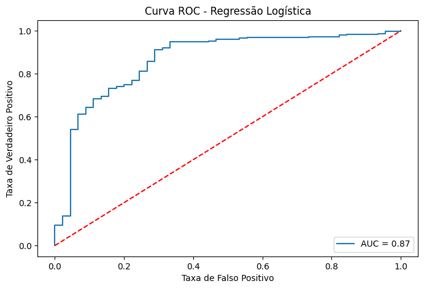

```python
# 10.2. Curva ROC para a Regressão Logística
from sklearn.preprocessing import LabelBinarizer

# Convertendo os rótulos para formato binário
lb = LabelBinarizer()
y_test_bin = lb.fit_transform(y_test)

# Obtendo as probabilidades da classe 'good'
y_score = log_reg.predict_proba(X_test)[:, 1]

fpr, tpr, thresholds = roc_curve(y_test_bin, y_score)
roc_auc = auc(fpr, tpr)

plt.figure(figsize=(8,5))
plt.plot(fpr, tpr, label='AUC = %0.2f' % roc_auc)
plt.plot([0, 1], [0, 1], 'r--')
plt.xlabel('Taxa de Falso Positivo')
plt.ylabel('Taxa de Verdadeiro Positivo')
plt.title('Curva ROC - Regressão Logística')
plt.legend(loc='lower right')
plt.show()
```

```python
# Faz a predição na base de teste
y_pred = rf_clf.predict(X_test)
```

```python
acuracia = accuracy_score(y_test, y_pred)
print("Acurácia na base de teste:", acuracia)
```

```
Acurácia na base de teste: 0.8892128279883382
```

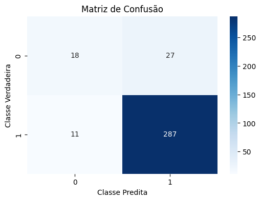

```
Relatório de Classificação:
               precision    recall  f1-score   support

         bom       0.62      0.40      0.49        45
        ruim       0.91      0.96      0.94       298

    accuracy                           0.89       343
   macro avg       0.77      0.68      0.71       343
weighted avg       0.88      0.89      0.88       343
```

```python
# Matriz de confusão
cm = confusion_matrix(y_test, y_pred)

# Plot da matriz de confusão
plt.figure(figsize=(6, 4))
sns.heatmap(cm, annot=True, fmt='d', cmap='Blues')
plt.xlabel('Classe Predita')
plt.ylabel('Classe Verdadeira')
plt.title('Matriz de Confusão')
plt.show()

# Relatório de Classificação
relatorio = classification_report(y_test, y_pred)
print("Relatório de Classificação:\n", relatorio)
```

## 10. Salvando o Modelo

Utilizando o Random Forest (modelo com bom desempenho) como exemplo, salvamos o modelo com `joblib` para uso futuro, evitando a necessidade de treinar novamente.

```python
# Salvando o modelo Random Forest treinado
joblib.dump(rf_clf, 'modelo_vinho.pkl')
print('Modelo salvo com sucesso em modelo_vinho.pkl')
```

```
Modelo salvo com sucesso em modelo_vinho.pkl
```

## 11. Ferramenta de Avaliação

```python
# Carrega o modelo salvo
modelo = joblib.load('modelo_vinho.pkl')

def avaliar_vinho(fixed_acidity, volatile_acidity, citric_acid, residual_sugar,
                  chlorides, free_sulfur_dioxide, total_sulfur_dioxide, density, pH, sulphates, alcohol):
    # Lista com os nomes das features, na mesma ordem utilizada no treinamento
    feature_names = ['fixed acidity', 'volatile acidity', 'citric acid', 'residual sugar',
                     'chlorides', 'free sulfur dioxide', 'total sulfur dioxide', 'density',
                     'pH', 'sulphates', 'alcohol']

    # Cria um DataFrame com os valores informados e as mesmas colunas
    dados = pd.DataFrame([[fixed_acidity, volatile_acidity, citric_acid, residual_sugar,
                           chlorides, free_sulfur_dioxide, total_sulfur_dioxide, density,
                           pH, sulphates, alcohol]], columns=feature_names)

    # Faz a predição usando o modelo carregado
    predicao = modelo.predict(dados)[0]
    return predicao
```

```python
# Exemplo de uso da ferramenta de avaliação:
resultado = avaliar_vinho(7.4, 0.70, 0.00, 1.9, 0.076, 11, 34, 0.9978, 3.51, 0.56, 9.4)
print("Classificação do vinho:", resultado)
```

```
Classificação do vinho: ruim
```

## 12. Conclusão

### Treinamento e Avaliação dos Modelos:

Foram treinados e avaliados diversos modelos de classificação – incluindo Regressão Logística, Árvore de Decisão, Random Forest e Gradient Boosting – para prever a qualidade dos vinhos com base em seus dados físico-químicos. Essa abordagem permitiu comparar o desempenho dos métodos e identificar o modelo mais robusto para a tarefa de classificação.

### Implicações Estratégicas e de Negócio:

Tomada de Decisão: A ferramenta facilita a identificação rápida de vinhos de alta e baixa qualidade, apoiando estratégias de seleção e marketing.

Otimização de Recursos: Ao prever a qualidade com precisão, é possível alocar melhor os investimentos e focar em produtos de maior valor agregado, potencializando o retorno sobre investimento (ROI).

Vantagem Competitiva: A integração da análise preditiva no fluxo de trabalho oferece uma vantagem competitiva, permitindo ajustes estratégicos baseados em dados concretos.

### Considerações Finais:

O projeto demonstra a eficácia das técnicas de aprendizado de máquina aplicadas à classificação de vinhos, unindo uma sólida análise exploratória com a implementação prática de um modelo preditivo. Essa abordagem não só reforça o papel da análise de dados na tomada de decisões estratégicas, como também exemplifica como transformar dados brutos em insights valiosos para o negócio.